# Proyección de Actividad Económica 2019-2020

Lic. Sebastian Castillo

2019-07-15

# Actividad Económica Argentina 2019-2020

En este informe presentamos una revisión del indicador de actividad económica argentina y su posible evolución en el corto plazo. Este documento fue eleborado en formato abierto para su reproducibilidad y análisis por el lector -puede consultarse por título en este [link](https://github.com/castillosebastian/castillosebastian.github.io/tree/master/mercado)-. Destaco los trabajos de Matt Dancho (proyección) y Walter Ramírez (economía) que contribuyeron a este informe, a los que remito en notas al pie.

## Evolución del Estimador Mensual

El informe de INDEC señala que **en abril de 2019 el estimador mensual de actividad económica (EMAE) cayó 1,3% respecto al mismo mes de 2018.**, pero seguidamente destaca que **el indicador desestacionalizado creció 0,8% y la tendencia-ciclo creció 0,1% respecto al mes anterior**. [^1] De esto podría inferirse una incipiente reactivación de la actividad económica en en los últimos meses y una posible reversión de la tendencia recesiva.

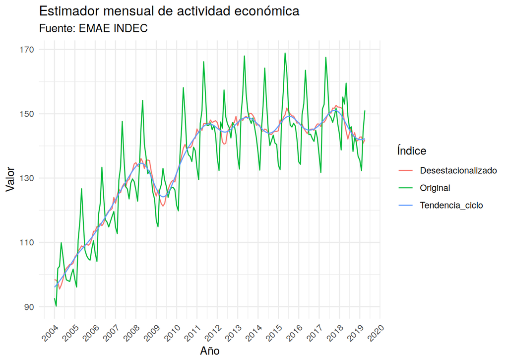

## Estimador Desestacionalizado

Sin perjuicio de ello, nótese que, luego de la caída del 2009, en los últimos 9 años el indicador estuvo lateralizado revelando la parálisis de nuestra económica. Como resalta Walter Ramírez[^2] -Gerente del Departamento de Investigación del Banco Supervielle- hoy nos encontramos con indicadores macro similares a los de hace nueva años, a lo que agregaría por mi parte: con una caída mayor a la experimentada en 2014 (con una crisis cambiaria histórica) y 2016-2017 (con una inflación cercana al 50%). Durante los últimos 100 años la tasa de inflación promedio fue de 105% anual con un máximo histórico de 3079% en 1989 -resalta en su informe la Cámara de Comercio-[^3].

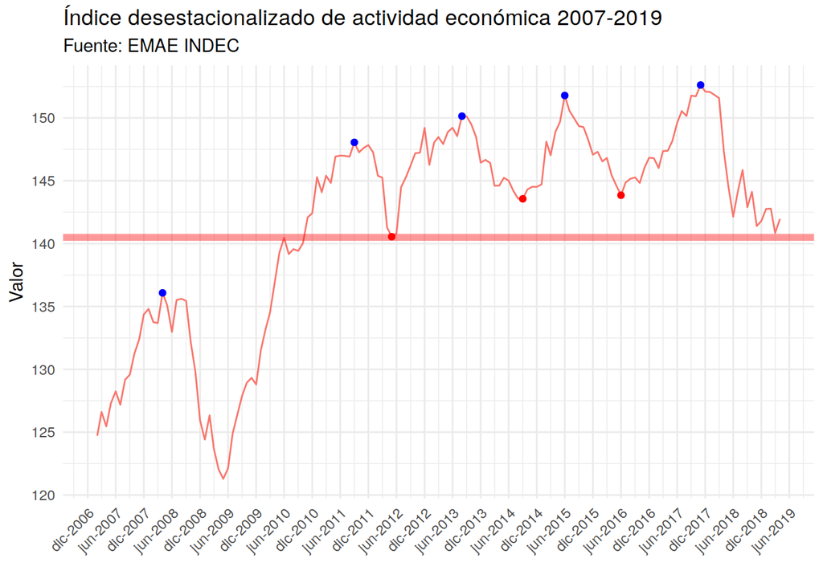

## Estimador de Actividad por Sector Económico

En el siguiente gráfico vemos la evolución del estimador sobre actividad económica en el período 2015-2019, coincidente con la Presidencia de Macri.

Vemos que en el 2018 se observa la fuerte caida del Sector Agropecuario que se propagó a los demás sectores (salvo Pesca, Ensañanza, Salud y Adm.Pública) evidenciando la acentuada dependencia que mantiene nuestra economía con ese sector. En abril de ese año el Ministerio de Agroindustria confirmaba una caída interanual del 20% en la producción granaria; excesos de lluvias a fines de 2017 (en Buenos Aires, La Pampa y Santa Fe) y una de las más importantes sequías de los últimos 50 años, llevaron a la declaración de emergencia en distintas regiones del país.[^4]

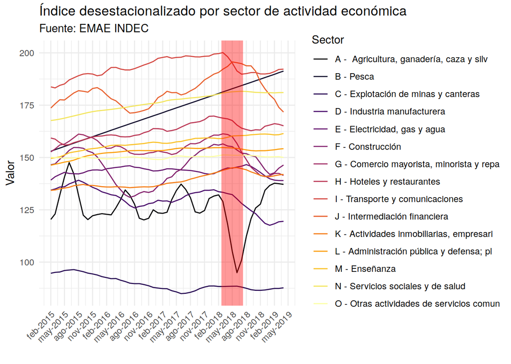

En este gráfico vemos los sectores económicos con más peso en el PIB nacional, con valor agregado bruto a precios básicos superior a los 50 mil millones y su estrecha relación con el Sector Agropecuario cuyo aporte al PIB es de 43.7 mil millones (año 2018).[^5]

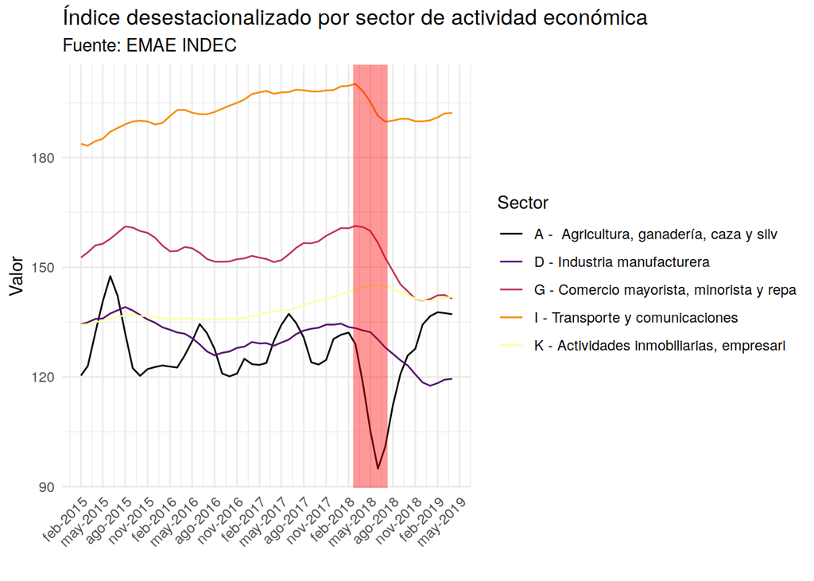

## Proyección de Actividad por Sector Económico

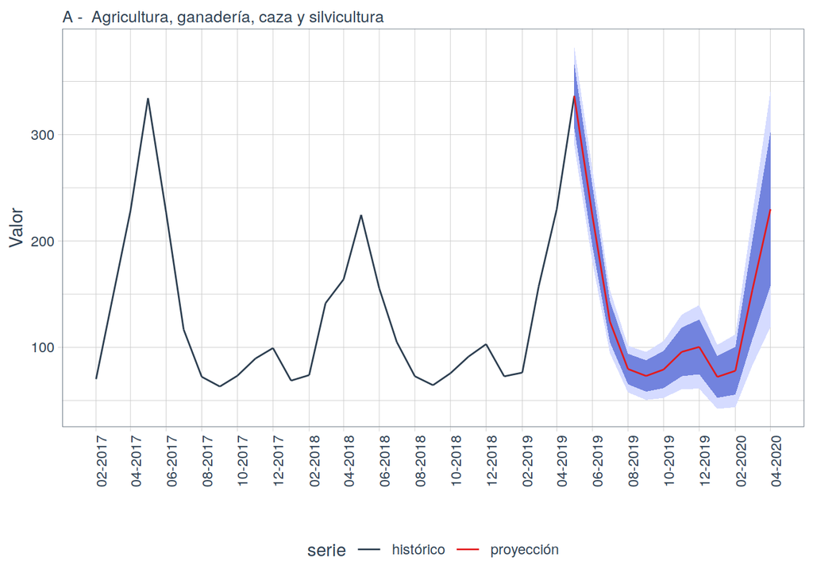

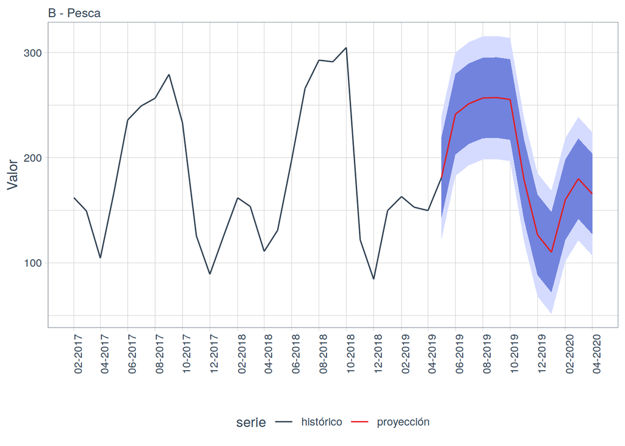

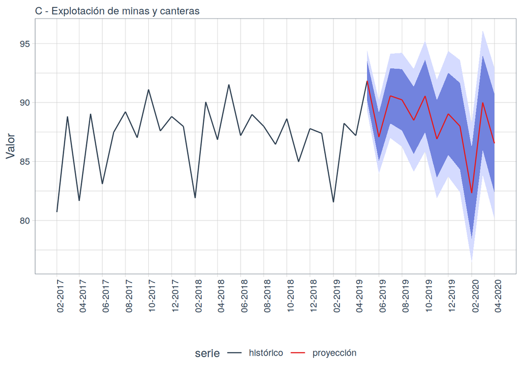

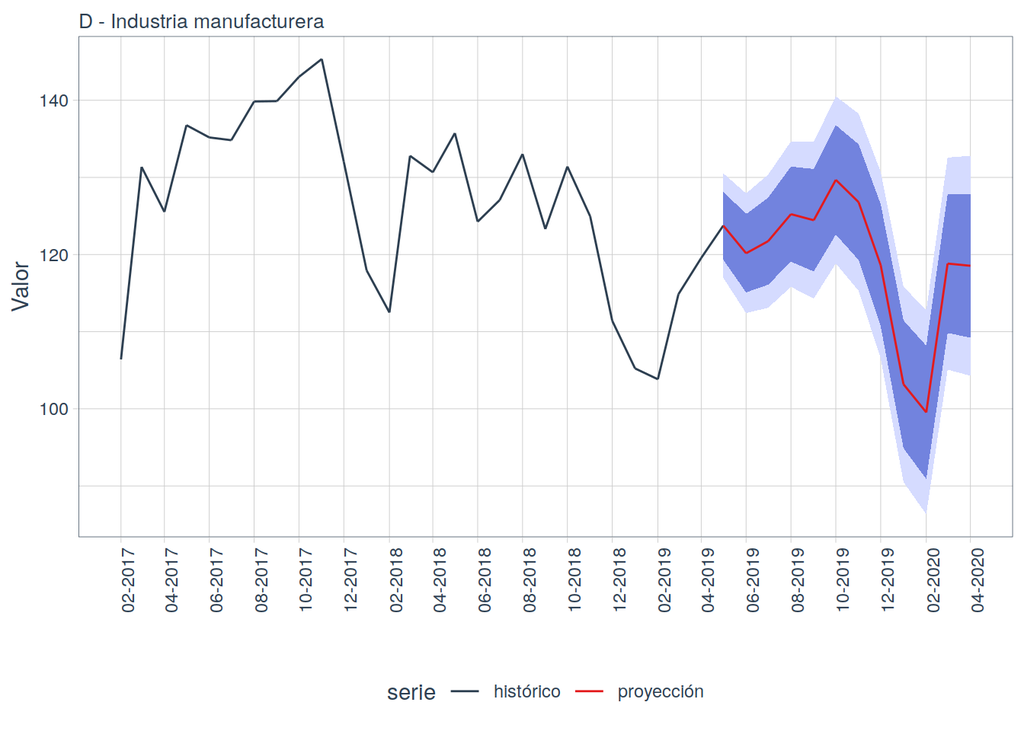

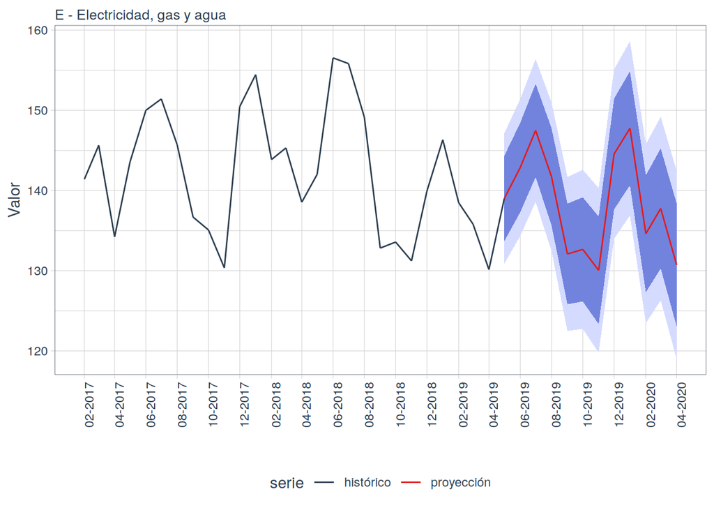

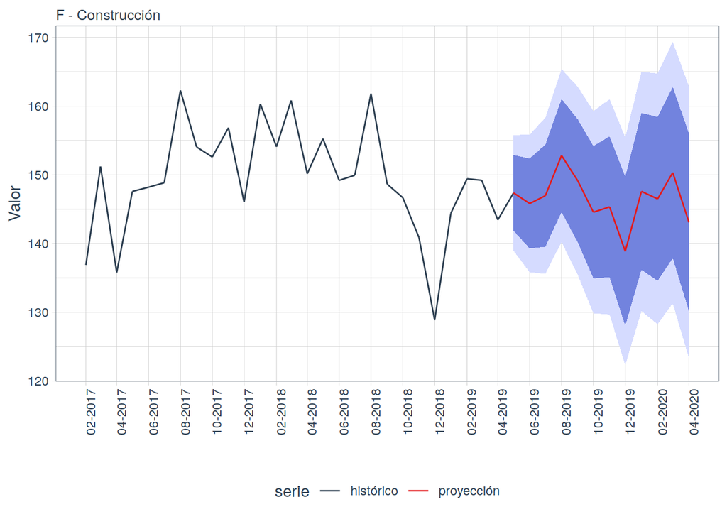

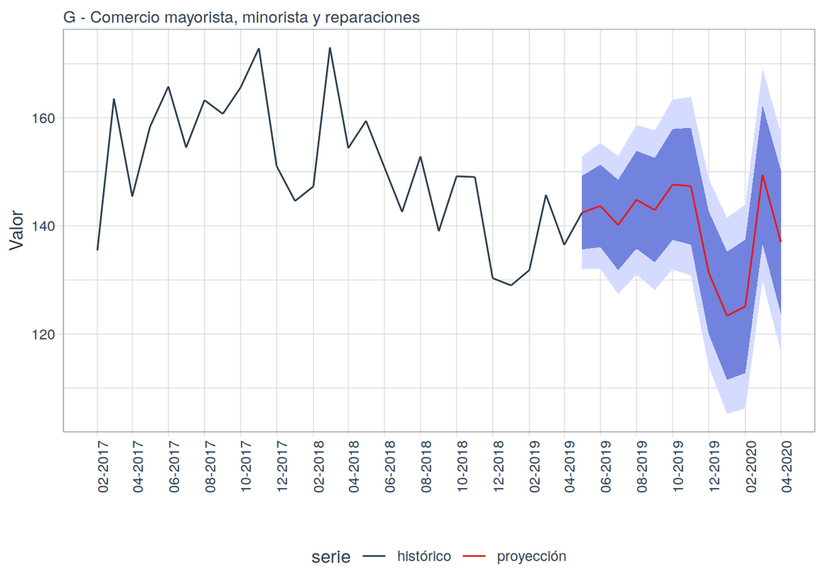

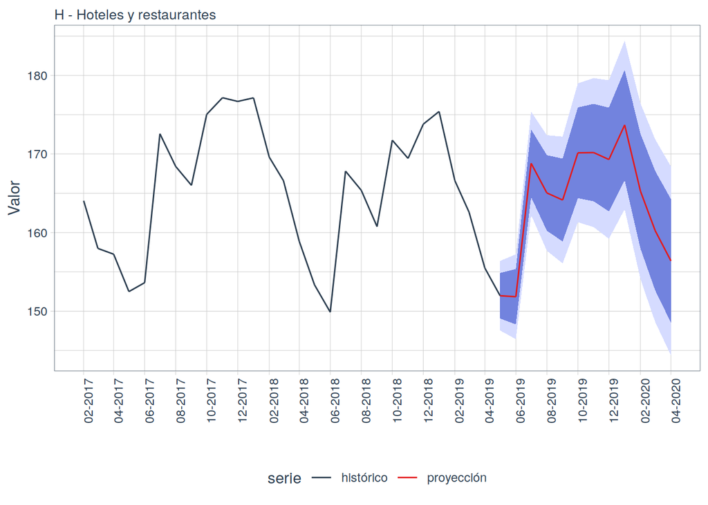

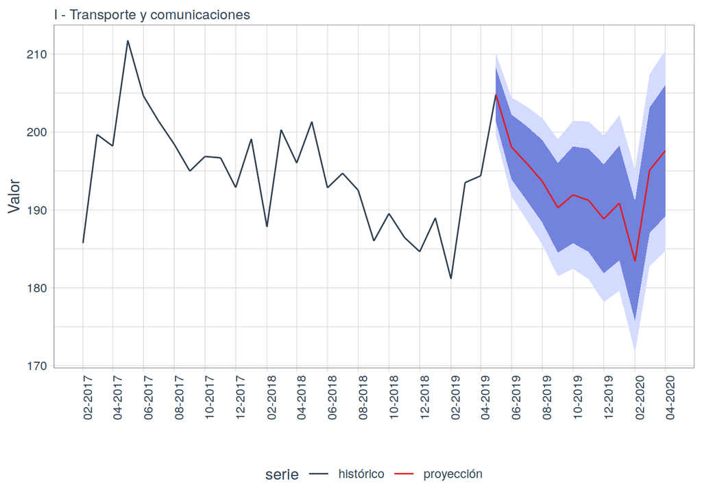

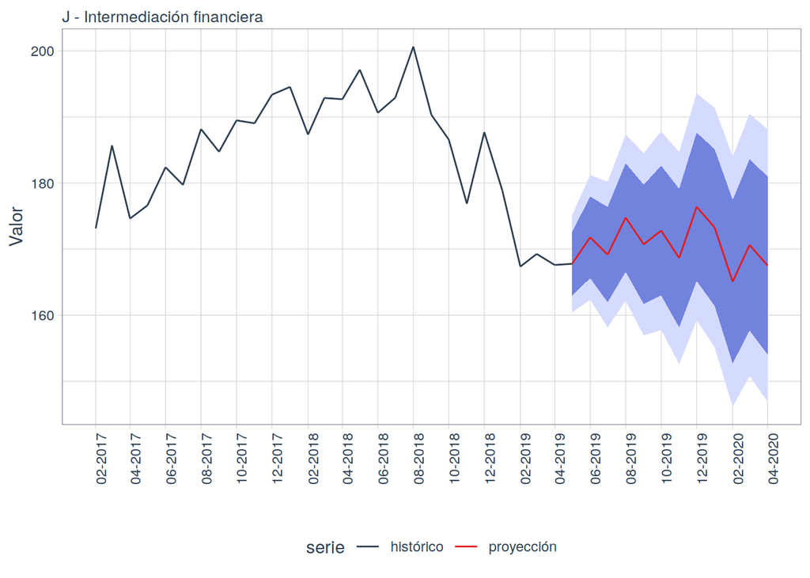

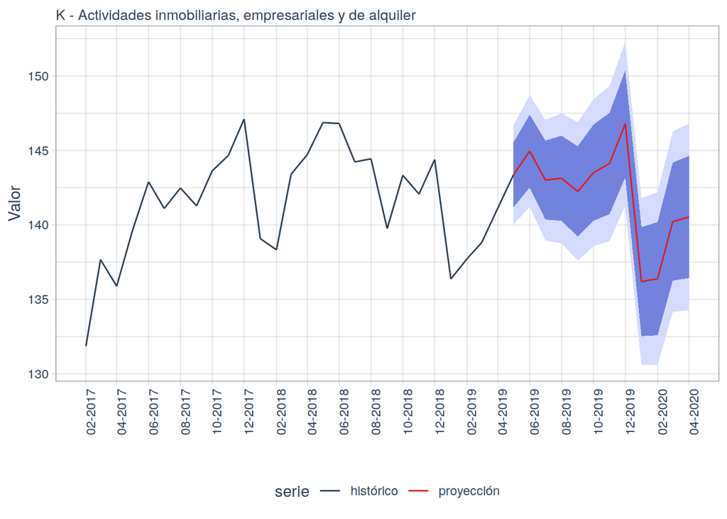

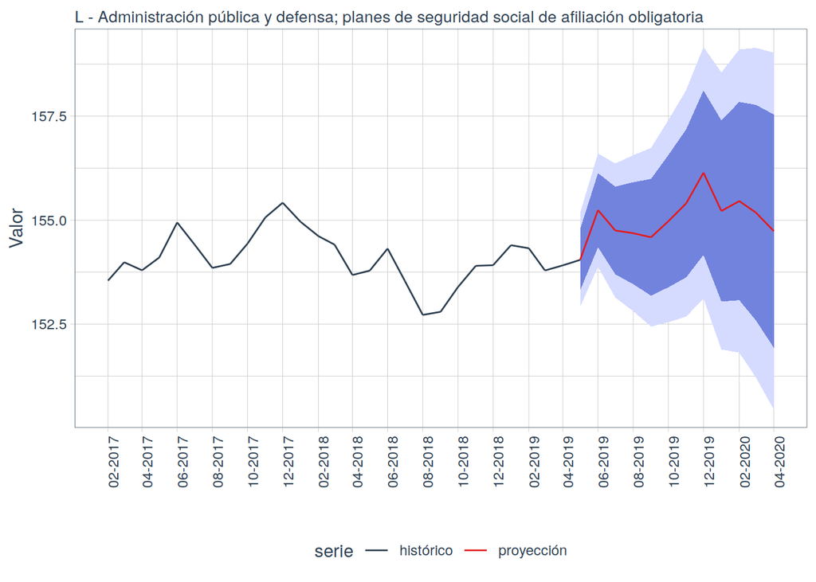

[2 more figures not shown]

## Consideraciones Finales

En próximas ediciones del informe agregaremos nuevas variables macroeconómicas (Inflación, Tasa de interés, Tipo de Cambio y Situación Fiscal) para completar el escenario nacional.

[^1]: INDEC, Estimador mensual de actividad económica, Abril de 2019, Informes Técnicos. Vol. 3, nº 119, ISSN 2545-6636, Cuentas nacionales. Vol. 3, nº 10., , URL = https://www.indec.gob.ar/indec/web/Nivel4-Tema-3-9-48.
[^2]: Walter Andrés Ramírez, Coyuntura económica y financiera preelectoral, invertirOnline, Streamed live on Jul 3, 2019, disponible publicamente en URL = https://www.youtube.com/watch?v=iAKVWbctubc&t=797s.
[^3]: Cámara Argentina de Comercio y Servicios (CAC), Unidad de Estudios y Proyectos Especiales (UEPE), informe del 13/07/2018 sobreHistoria de la inflación en Argentina, accesible en URL = https://www.cac.com.ar/data/documentos/10_Historia%20de%20la%20inflaci%C3%B3n%20en%20Argentina.pdf.
[^4]: “El Gobierno estimó una caída del 29% para la cosecha de soja y pérdidas por USD 5.000 millones”, Infobae, https://www.infobae.com/campo/2018/04/20/el-gobierno-estimo-una-caida-del-29-para-la-cosecha-de-soja-y-perdidas-por-usd-5-000-millones/.
[^5]: INDEC, Informe de avance del nivel de actividad - Primer trimestre de 2019, Cuadro 4. Producto interno bruto, por categoría de tabulación. Valores trimestrales en millones de pesos a precios de 2004, acceso público en https://www.indec.gob.ar/uploads/informesdeprensa/pib_06_19216BF7828F.pdf.
[^6]: Gracias al excelente caso de uso elaborado por Matt Dancho utilizando R, en “Forecasting Time Series Groups in the tidyverse”, 2018-03-03, accesible publicamente en URL = https://cran.rstudio.com/web/packages/sweep/vignettes/SW01_Forecasting_Time_Series_Groups.html.